# Using Functions in CondQuant.R

Matt Dawson

10/14/2017

## Introduction

The idea behind `CondQuant.R` is to estimate conditional quantiles nonparametrically. For this, the assumed data is bivariate $(X, Z)$; given the conditonal distribution $F(z|x)$, the target is the quantile $F^{-1}(\alpha|x)$. Below is a short vignette describing how to use the code from `CondQuant.R`. In terms of this repo, this is not the end product, but more of an auixilliary result.

## Sample Data

Let’s generate some data to see how to use these functions.

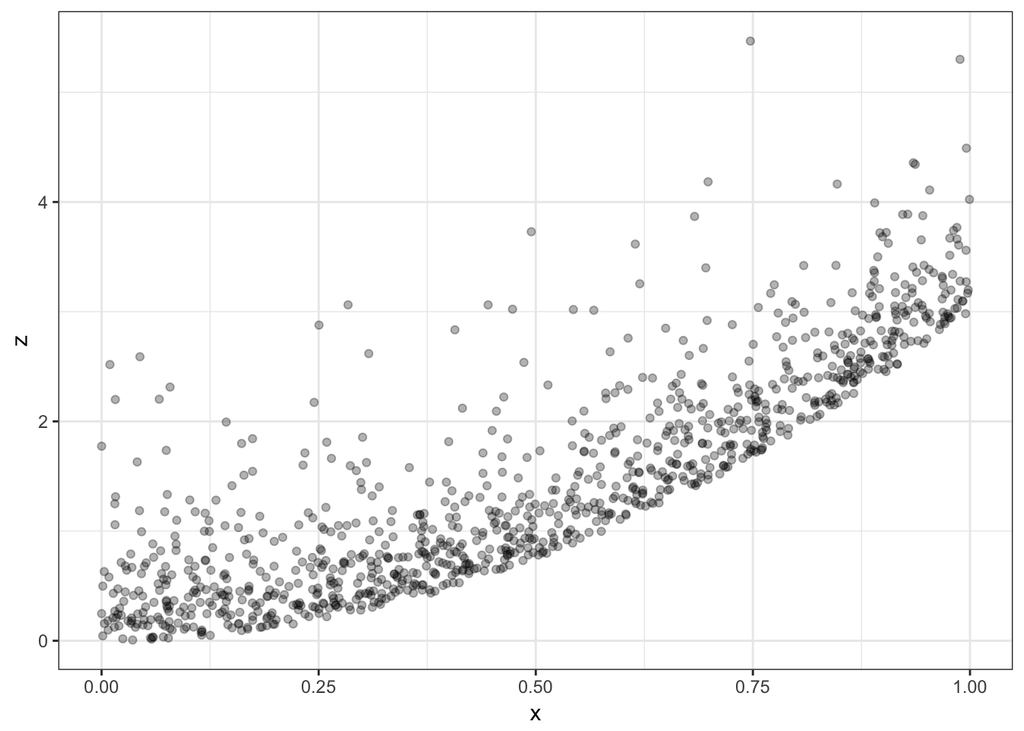

```r
library(tidyverse)
source('CondQuant.R')

# Nonlinear with non-Gaussian noise
x <- runif(n=1000,
           min=0,
           max=1)
z <- 3*x^2 + rgamma(n=length(x),
                    shape=1,
                    rate=2)
dat <- as_tibble(data.frame(x = x,
                            z = z))

# Plot it
ggplot(dat, aes(x=x, y=z)) +
  geom_point(alpha=.3) +
  theme_bw()
```

## Calculating Conditional Quantiles

The purpose of `CondQuant()` is to estimate conditional quantiles; in terms of the variables used, this is the $\alpha$ conditional quantile of $Z$ given $X$. There are several arguments that must be provided, including bandwidth parameters, as this is a nonparametric method. Currently, only the Gaussian kernel is supported.

- `alpha` is a vector of probabilities for quantile estimation.
- `x0` is the conditioning variable. We estimate the conditional quantile of $Z$ given $X=x_0$.
- `zGrid` is a grid over the range of $Z$ to estimate the quantiles.
- `z` is a vector which are observations of $Z$.
- `x` is a vector which are observations of $X$.
- `b.z` is the bandwidth to be used for smoothing in the $Z$-direction.
- `b.x` is the bandwidth to be used for smoothing in the $X$-direction.

So let’s estimate the $.25$ quantile for this data conditional on $X = .5$.

```r
CondQuant(alpha=.25,
          x0=.5,
          zGrid=seq(0, 7, .01),
          z=dat$z,
          x=dat$x,
          b.z=.05,
          b.x=.03)
```

```
## [1] 0.87
```

Finally, we can use this function to estimate several quantiles over the entire range of $X$.

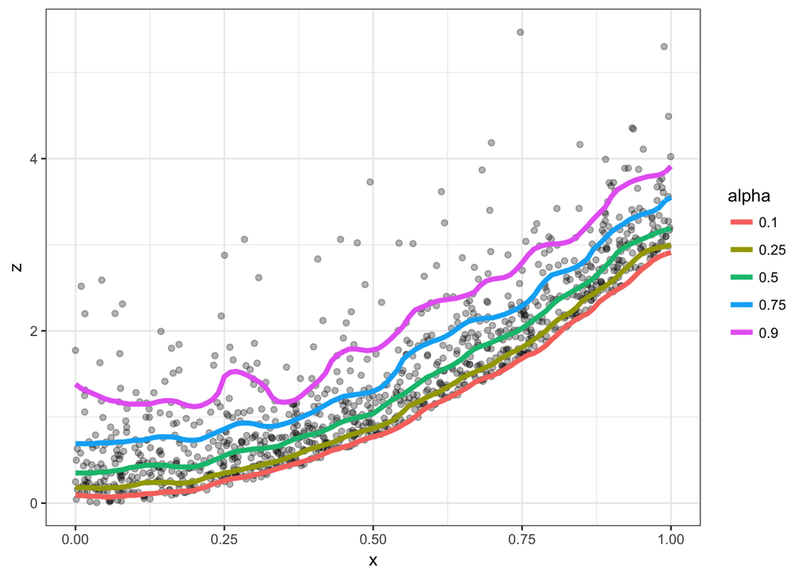

```r
# Define a range of x0s and alphas and loop over them.
xRange <- seq(0, 1, .01)
alphas <- c(.1, .25, .5, .75, .9)
quantileMat <- t(sapply(xRange, function(y) {
  CondQuant(alpha=alphas,
            x0=y,
            zGrid=seq(0, 7, .01),
            z=dat$z,
            x=dat$x,
            b.z=.05,
            b.x=.03)
}))

# Make a nice data frame for plotting
quantiles <- as_tibble(data.frame(x = rep(xRange, length(alphas)),
                                  alpha = factor(rep(alphas,
                                                     each=length(xRange))),
                                  quant = c(quantileMat)))

# Plot quantiles with data
ggplot(dat, aes(x=x, y=z)) +
  geom_point(alpha=.3) +
  geom_line(data=quantiles,
            aes(x=x, y=quant, group=alpha, color=alpha),
            size = 1.5) +
  theme_bw()
```